# Tutorial 2

Maria Korochkina

06/03/20

## Load packages

```r
library("data.table")
library("curl")
library("ggplot2")

# and don't forget:
rm(list=ls())
```

## Recap

On Wednesday, Matt talked about two important concepts, **central tendency** and **spread** (or variability) of a sample.

### Measures of central tendency

Central tendency tells us where most of the values in our sample are clustered, and we can measure it with mean, median and mode.

The **mean** ($\overline{x}$) of a sample of dependent variable values $x_{1}, x_{2}, \dots, x_{n}$ can be calculated using the following formula:

$$\overline{x} = \frac{x_1 + x_2+ \dots+ x_n}{n} = \frac{\sum_{i=1}^{n} x_i}{n}$$

Here is an example:

```r
x <- c(11, 17, 94, 80, 67, 15, 3, 8, 6)
mean(x)
```

```
## [1] 33.44444
```

As Matt illustrated in the lecture, the mean is very sensitive to outliers because they can skew the average of the values. This is why we might sometimes want to use the **median** - the middle number in a sorted, ascending or descending, list of numbers.

```r
median(x)
```

```
## [1] 15
```

Another measure of central tendency is the **mode** - the number which appears most often in a set of numbers. Unike mean and median, mode can have both numeric and character data. R does not have a standard in-built function to calculate mode. We can create a function to calculate mode of a data set in R. This function takes the vector as input and gives the mode value as output:

```r
# Define a function:
getmode <- function(v) {
   uniqv <- unique(v)
   uniqv[which.max(tabulate(match(v, uniqv)))]
}

# Create a vector with numbers:
v <- c(2,1,2,3,1,2,3,4,1,5,5,3,2,3)

# Calculate the mode using the function defined above:
getmode(v)
```

```
## [1] 2
```

```r
# For a vector of characters:
v2 <- c("o","it","the","it","it")
getmode(v2)
```

```
## [1] "it"
```

The mode is not as useful for us as the mean and the median. One of reasons is that there could be a data set where there is no mode at all as all values appear in a vector the same number of times.

### Measures of spread / dispersion

When dealing with a sample, one of the most common measures of spread that quantifies how much each individual value $x_i$ deviates (on average) from the mean value $\overline{x}$ is **variance**. The square root of variance is called **standard deviation**. A low standard deviation indicates that the data points tend to be close to the mean of the data set, while a high standard deviation indicates that the data points are spread out over a wider range of values.

It is important not to confuse the standard deviation of a sample (denoted as $s$) with the standard eviation of a population (denoted as $\sigma$). The former is used when we need to find SD of some part (or a segment) of a population:

$$s = \sqrt{\frac{(x_1 - \boldsymbol{\overline{x}})^2 + (x_2 - \boldsymbol{\overline{x}})^2 + \dots + (x_n - \boldsymbol{\overline{x}})^2}{n-1}} = \sqrt{\frac{1}{n-1} \sum_{i=1}^{n}(x_i - \boldsymbol{\overline{x}})^2}$$

We use the latter if we deal with the whole population:

$$\sigma = \sqrt{\frac{(x_1 - \boldsymbol{\mu})^2 + (x_2 - \boldsymbol{\mu})^2 + \dots + (x_n - \boldsymbol{\mu})^2}{n}} = \sqrt{\frac{1}{n} \sum_{i=1}^{n}(x_i - \boldsymbol{\mu})^2}$$

where $\mu$ is the mean of a population (NB: note that the formulae are not identical!).

Similarly, the sample variance is denoted as $s^2$, while the population variance is denoted as $\sigma^2$.

In descriptive statistics, we generally deal with data available in a **sample**, not in a population.

We can calculate both variance and SD in R using the following functions:

```r
## Variance:
var(x)
```

```
## [1] 1300.278
```

```r
## standard deviation:
sd(x)
```

```
## [1] 36.05936
```

Another measure of spread in descriptive statistics is **range**. It is the difference between the lowest and highest value.

```r
## Maximal value:
max(x)
```

```
## [1] 94
```

```r
## Minimal value:
min(x)
```

```
## [1] 3
```

```r
## Both together:
range(x)
```

```
## [1]  3 94
```

```r
## Difference between max and min:
diff(range(x))
```

```
## [1] 91
```

Let’s simulate some data and then calculate descriptive statistics for it:

```r
## Generate some data from the normal distribution:
numbers <- rnorm(100, mean = 20, sd = 2.5)
## add id:
id <- 1:length(numbers)
## create a data.table:
data2 <- data.table(id, numbers)

## What is the mean value of our sample? Can you guess? :)
mean <- data2[, mean(numbers)]
## Median:
data2[, median(numbers)]
```

```
## [1] 20.12446
```

```r
## Mode:
data2[, getmode(numbers)]
```

```
## [1] 19.00049
```

```r
## Variance:
var <- data2[, var(numbers)]
## SD:
sd <- data2[, sd(numbers)]
## Minimal value:
data2[, min(numbers)]
```

```
## [1] 14.80612
```

```r
## Maximal value:
data2[, max(numbers)]
```

```
## [1] 24.99075
```

```r
## Both together:
data2[, range(numbers)]
```

```
## [1] 14.80612 24.99075
```

```r
## Difference between max and min:
range <- data2[, diff(range(numbers))]
```

Let’s plot it now:

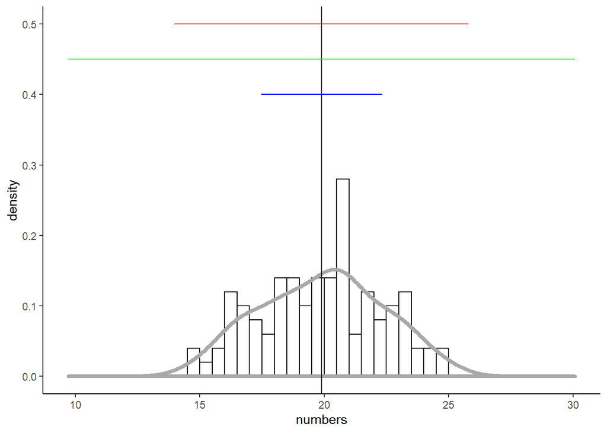

```r
b <- seq(10, 30, by = .5)
ggplot(data2, aes(x = numbers)) +
  geom_histogram(aes(y=..density..), breaks = b, col = "black", fill = "white") +
  geom_density(colour = "darkgrey", size = 1.5) +
  geom_vline(xintercept = mean, colour = "black") +
  geom_segment(aes(x = mean - var, xend = mean + var, y = .5, yend = .5), colour = "red") +
  geom_segment(aes(x = mean - sd, xend = mean + sd, y = .4, yend = .4), colour = "blue") +
  geom_segment(aes(x = mean - range, xend = mean + range, y = .45, yend = .45), colour = "green") +
    theme(
        axis.title = element_text(size = 14),
        axis.text = element_text(size = 12)) +
  theme_classic()
```

What would happen if we set `b` to `seq(0,15, by = .5)`?

To summarise, in research, we usually aim to:

- estimate the mean value of a sample *and*
- determine how certain we are about the accuracy of our sample estimate.

## Let’s practice!

### Basic graphs with discrete x-axis

- `geom_bar`
- `geom_line`
- `geom_boxplot`
- `geom_violin`
- `geom_point`
- `facet_wrap`

With bar graphs, there are two different things that the heights of bars commonly represent:

- the count of cases for each group - typically, each x value represents one group. This is done with `stat = "bin"`, which calculates the number of cases in each group;
- the value of a column in the data set. This is done with `stat = "identity"`, which leaves the y values unchanged.

In ggplot2, the default is to use `stat = "bin"` so that the bar height represents the count of cases.

To illustare this, we will work with the `tips` dataset from the package `reshape2`. One waiter recorded information about each tip he received over a period of a few months working in one restaurant.

```r
rm(list=ls())

library("reshape2") # don't forget to install this package first!

tips <- data.table(tips)
head(tips)
```

```
##    total_bill  tip    sex smoker day   time size
## 1:      16.99 1.01 Female     No Sun Dinner    2
## 2:      10.34 1.66   Male     No Sun Dinner    3
## 3:      21.01 3.50   Male     No Sun Dinner    3
## 4:      23.68 3.31   Male     No Sun Dinner    2
## 5:      24.59 3.61 Female     No Sun Dinner    4
## 6:      25.29 4.71   Male     No Sun Dinner    4
```

```r
str(tips)
```

```
## Classes 'data.table' and 'data.frame':   244 obs. of  7 variables:
##  $ total_bill: num  17 10.3 21 23.7 24.6 ...
##  $ tip       : num  1.01 1.66 3.5 3.31 3.61 4.71 2 3.12 1.96 3.23 ...
##  $ sex       : Factor w/ 2 levels "Female","Male": 1 2 2 2 1 2 2 2 2 2 ...
##  $ smoker    : Factor w/ 2 levels "No","Yes": 1 1 1 1 1 1 1 1 1 1 ...
##  $ day       : Factor w/ 4 levels "Fri","Sat","Sun",..: 3 3 3 3 3 3 3 3 3 3 ...
##  $ time      : Factor w/ 2 levels "Dinner","Lunch": 1 1 1 1 1 1 1 1 1 1 ...
##  $ size      : int  2 3 3 2 4 4 2 4 2 2 ...
##  - attr(*, ".internal.selfref")=<externalptr>
```

We see that the waiter collected several variables:

- `total_bill`: bill in US dollars
- `tip`: tip in US dollars
- `sex`: sex of the bill payer
- `smoker`: whether there were smokers in the party
- `day`: day of the week
- `time`: time of the day
- `size`: size of the party

and that this dataset has 244 rows and 7 columns.

Let’s inspect this dataset:

**How many observations per day do we have?**

```
##     day  N
## 1:  Sun 76
## 2:  Sat 87
## 3: Thur 62
## 4:  Fri 19
```

Let’s plot this using the default `stat = "bin"`:

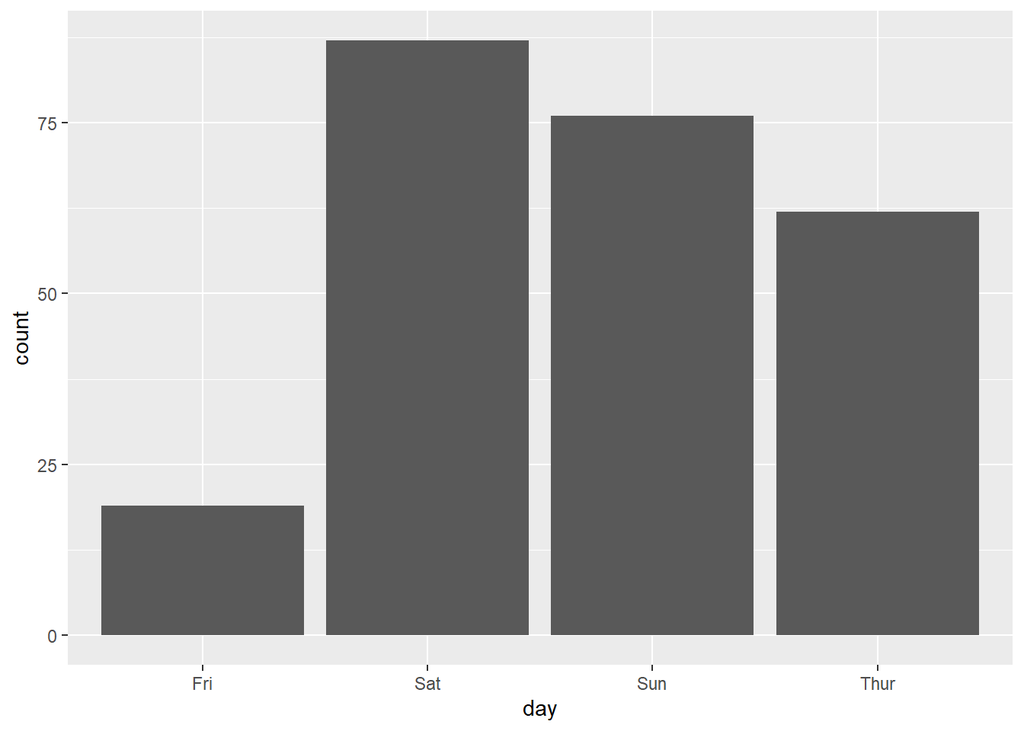

**How many observations per time of day do we have?**

```
##      time   N
## 1: Dinner 176
## 2:  Lunch  68
```

Let’s plot this too:

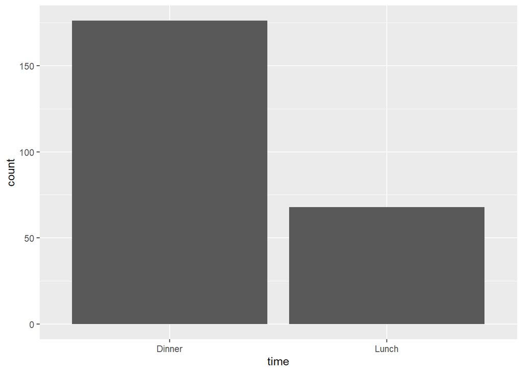

**How much on average did the customers pay depending on the time of day?**

```
##      time     mean
## 1: Dinner 20.79716
## 2:  Lunch 17.16868
```

To plot this, we will need `stat = "identity"`:

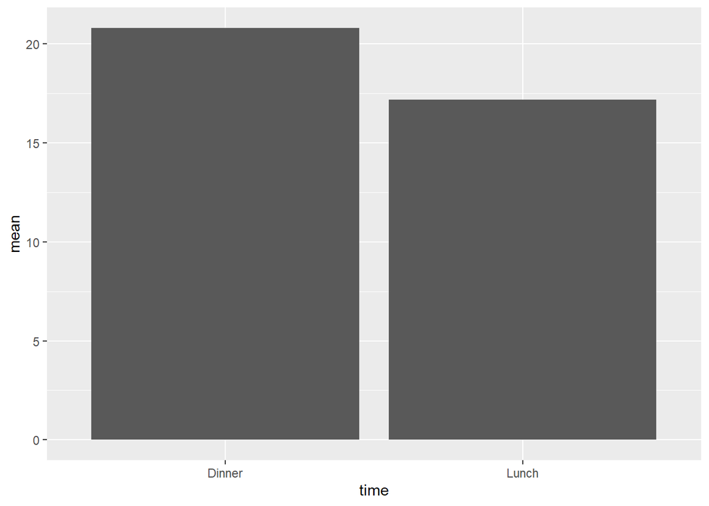

This looks boring. Let’s make it prettier!

Add colors:

*Hint: use argument `fill =` in global `aes()`!*

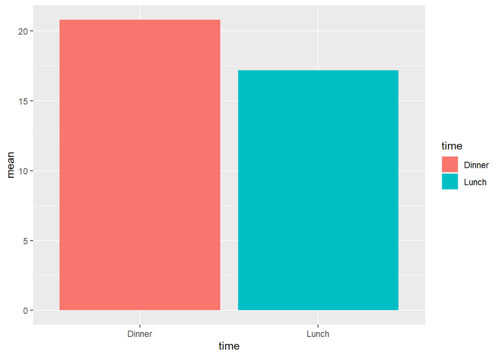

Add black outlines:

*Hint: use argument `color =` in `geom_bar()`!*

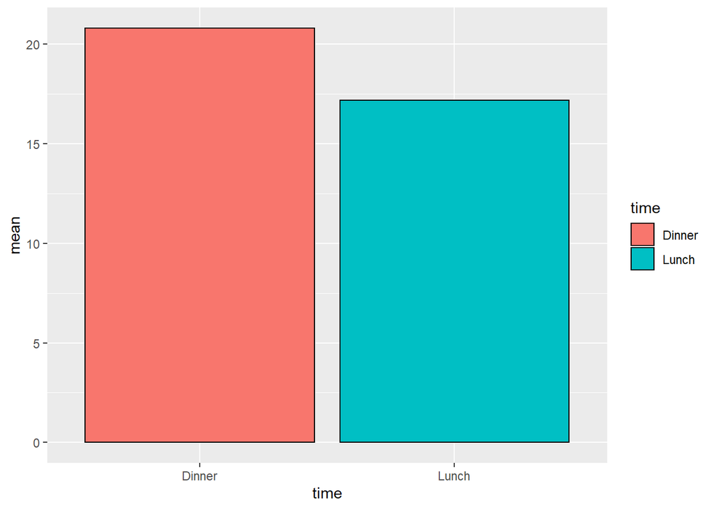

Change colors (e.g. you can use RGB, HTML or Hex color codes for this):

*Hint: add `scale_fill_manual()` to the previous plot!*

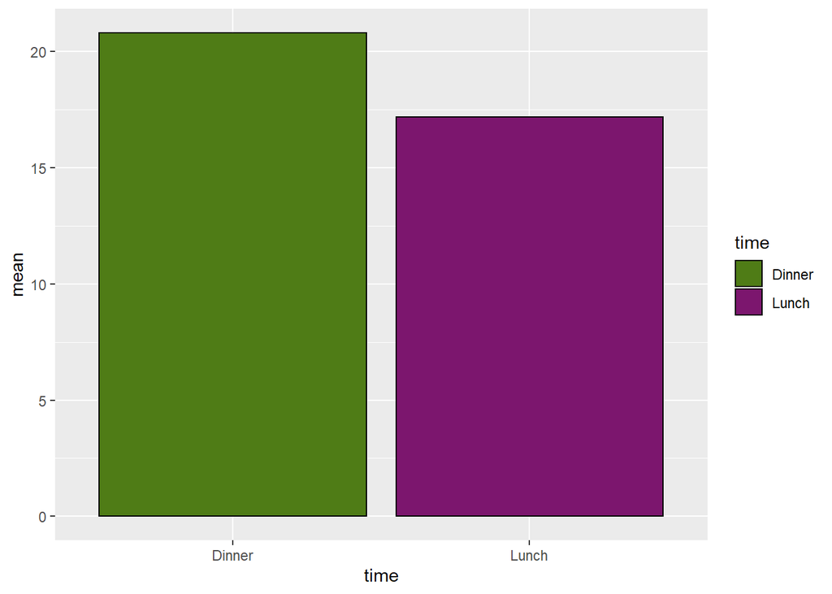

Add labels for x and y axes and a title:

*Hint: add `xlab()`, `ylab()` and `ggtitle()`!*

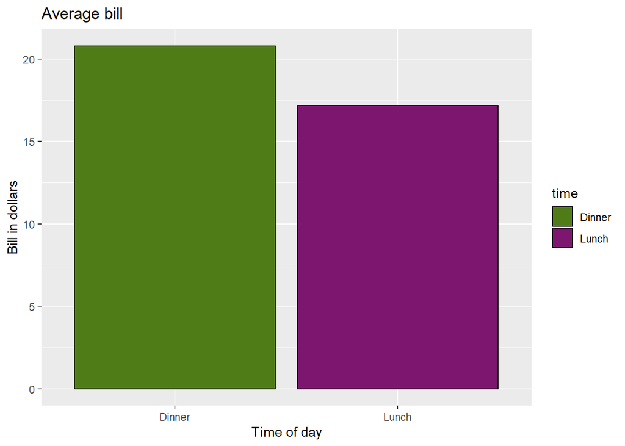

Remove the legend, since the information is redundant:

*Hint: set `guides()` for `fill =` to `FALSE`!*

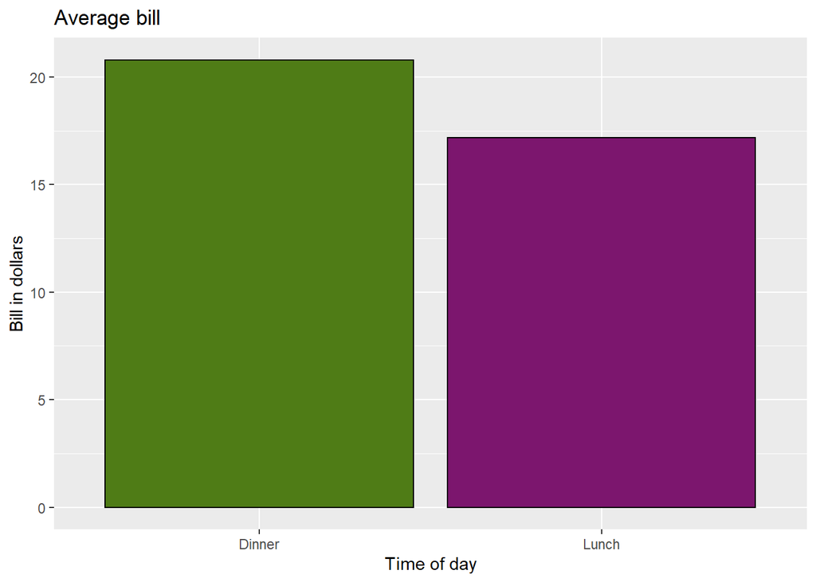

Looks better, doesn’t it?

We can plot this using a line graph (`geom_line`) as well. For a line graph, the data points must be grouped so that R knows which points to connect. We provide this information by using `group =`. If all points should be connected, we say `group = 1`. When more variables are used and multiple lines are drawn, the grouping for lines is usually done by variable (as in the sex example).

For a line graph, the data points must be grouped so that R knows which points to connect. We provide this information by using `group =`. If all points should be connected, we say `group = 1`. When more variables are used and multiple lines are drawn, the grouping for lines is usually done by variable (as in this example).

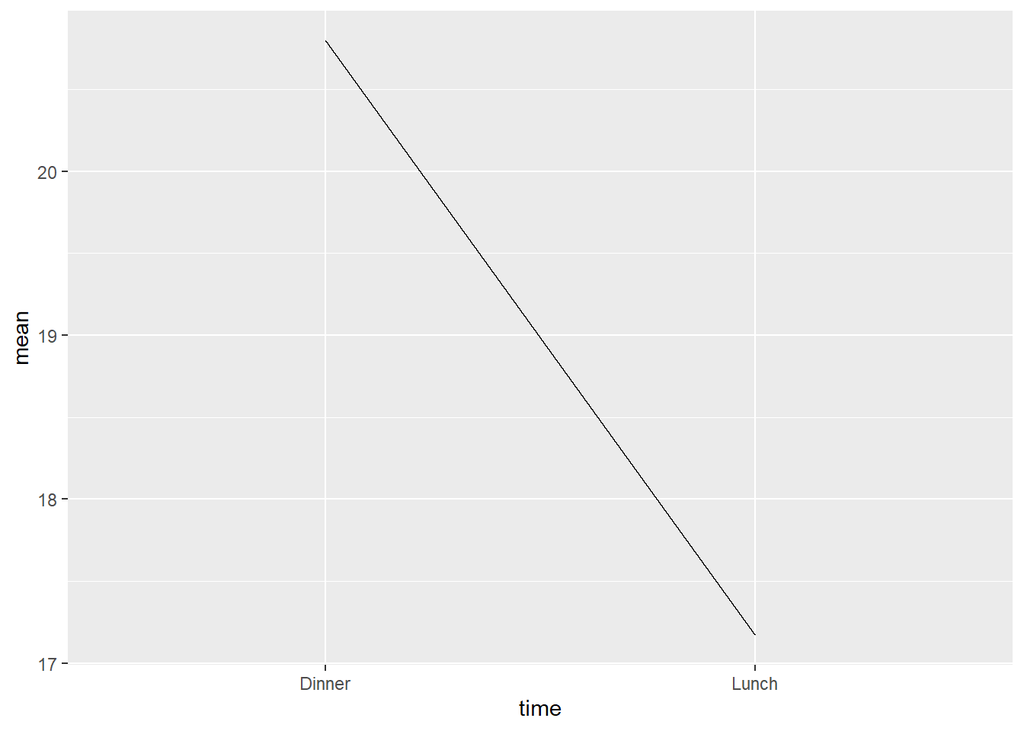

Let’s play a bit with this one. Add points:

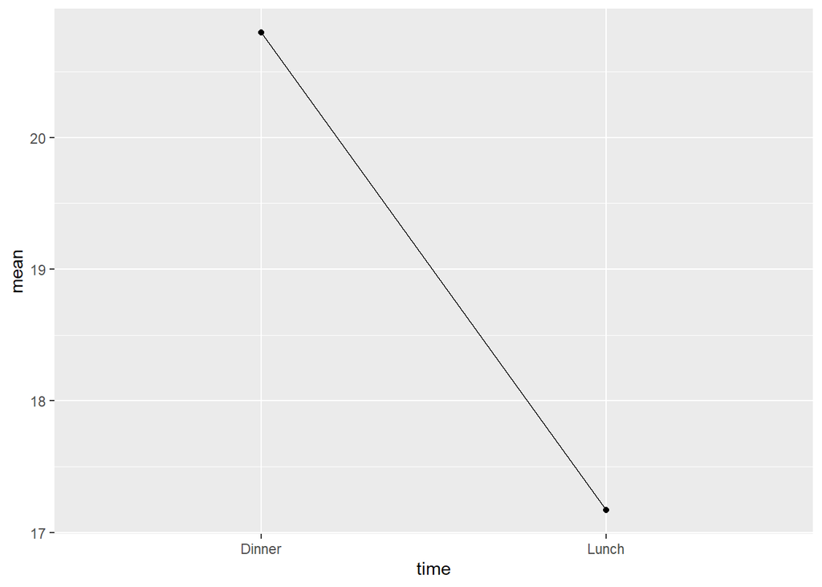

*Hint: use arguments such as `color =`, `linetype =`, `size =`, `shape =` and `fill =`!*

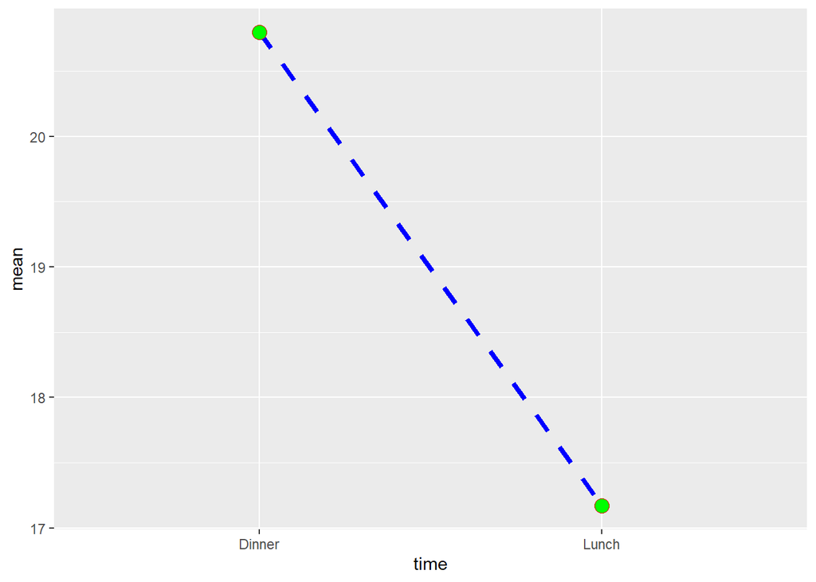

Now change the y-range to go from 0 to the mean value and change axis labels:

*Hint: use `expand_limits()`!*

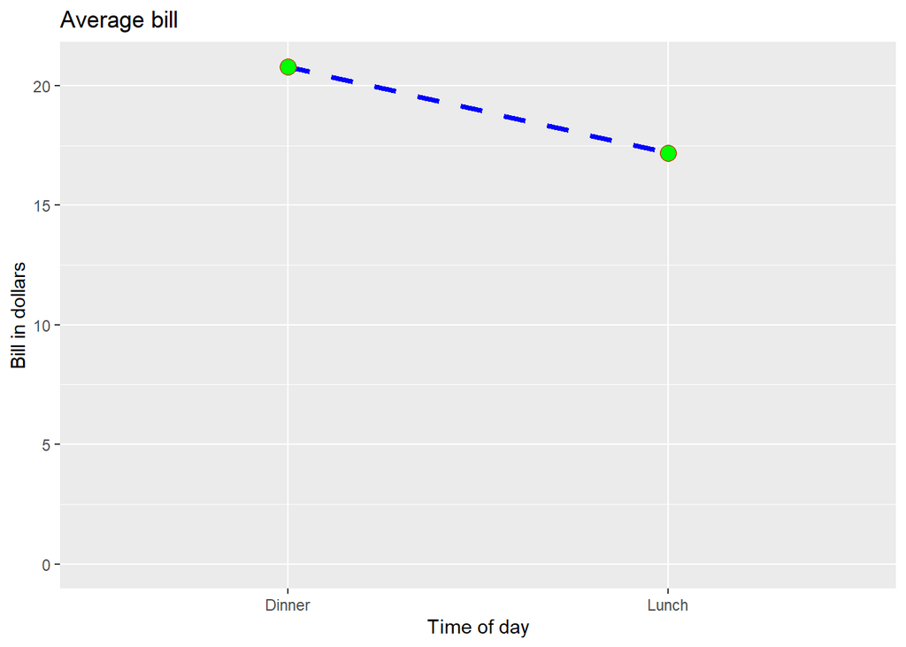

Cool! Let’s continue!

**How much on average did the customers pay depending on the time of day and day of the week?**

```
##      time  day     mean
## 1: Dinner  Sun 21.41000
## 2: Dinner  Sat 20.44138
## 3:  Lunch Thur 17.66475
## 4: Dinner  Fri 19.66333
## 5:  Lunch  Fri 12.84571
## 6: Dinner Thur 18.78000
```

To plot this, we will need `stat = "identity"`:

*Hint: check out `position_dodge()`, `scale_fill_hue()`!*

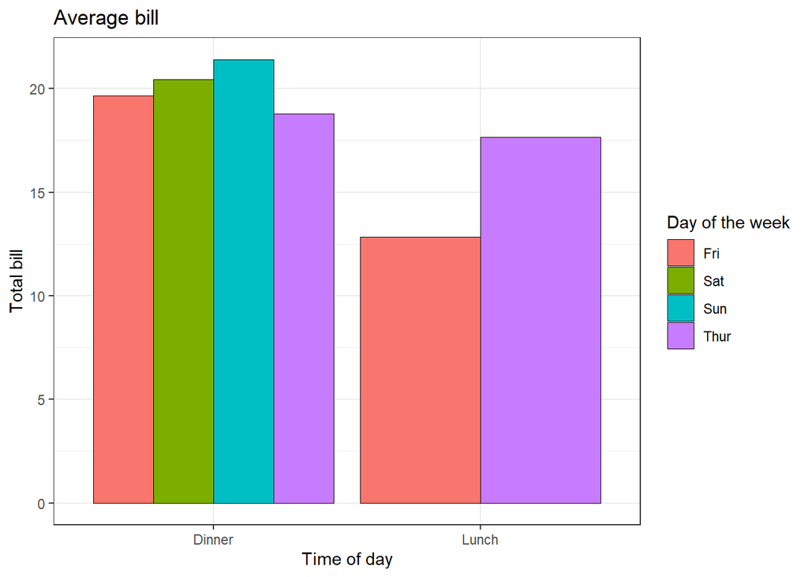

What about a box-plot?

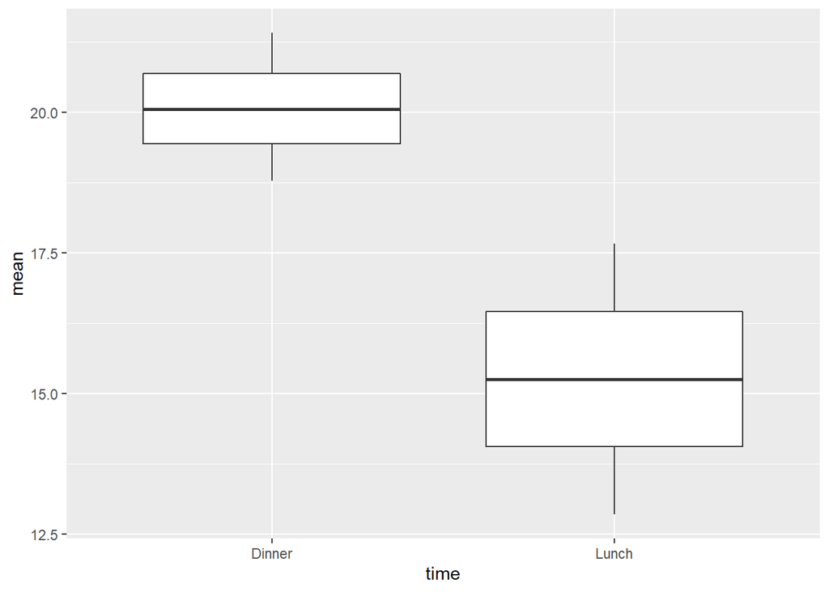

Why do you think there are not “boxes” for Sat and Sun?

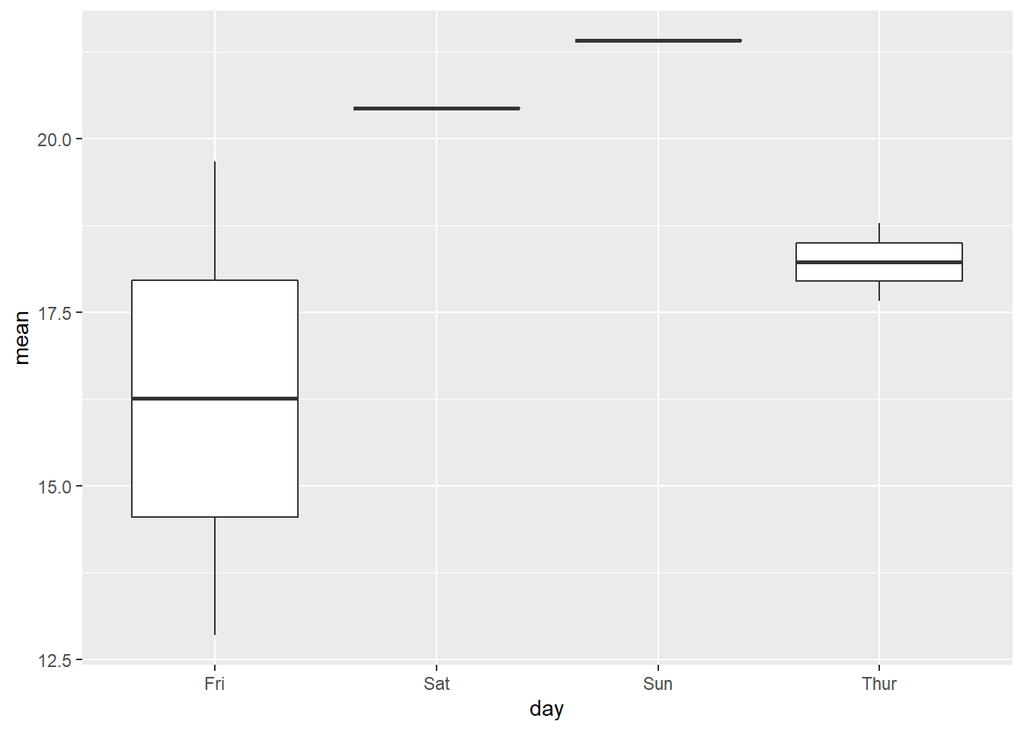

Hm, what about simple points? Are these plots useful in this scenario?

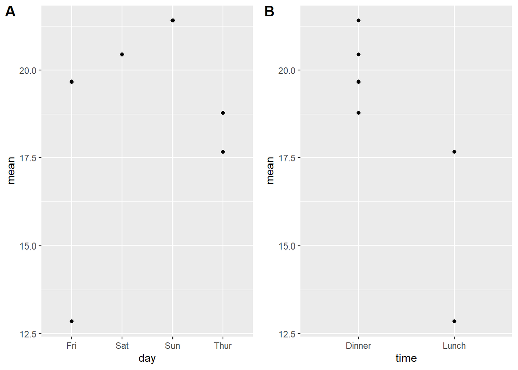

```
##      time    sex     mean
## 1: Dinner Female 19.21308
## 2: Dinner   Male 21.46145
## 3:  Lunch   Male 18.04848
## 4:  Lunch Female 16.33914
```

Create a bar plot:

*By now you should be able to replicate this plot! Check the hints above if unsure*

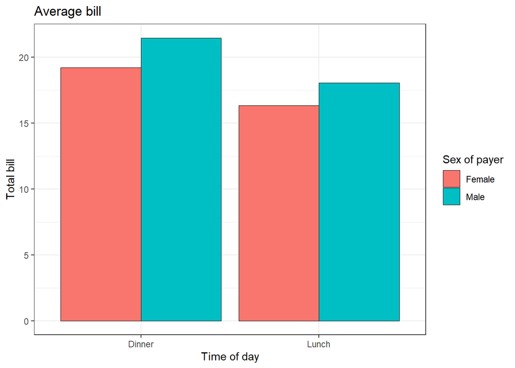

In theory, we could use `facet_wrap` here; however, this is more useful when we have more than two levels in our independent variable:

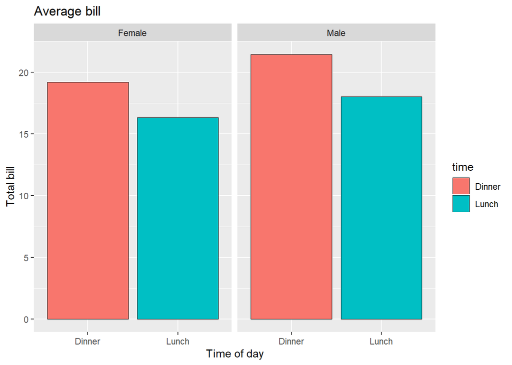

We can illustrate this using `geom_line` as well:

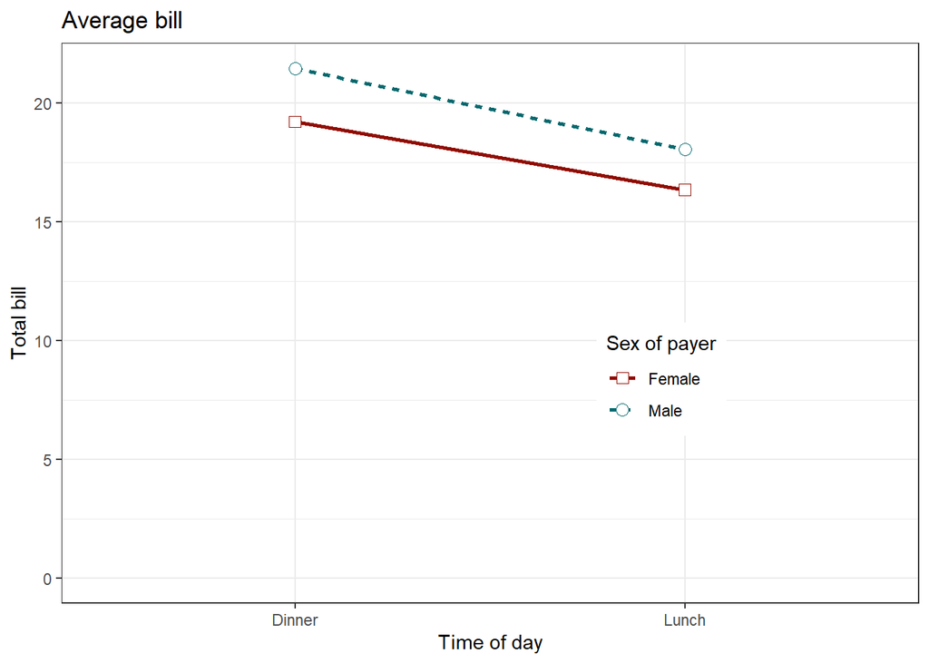

```r
ggplot(c, aes(x = time, y = mean, group = sex, shape = sex, colour = sex)) +
   # Set linetype by sex:
    geom_line(aes(linetype = sex), size = 1) +
    geom_point(size = 3, fill = "white") +
    expand_limits(y = 0) +
    # Use darker colors (lightness = 30):
    scale_colour_hue(name = "Sex of payer", l = 30)  +
    # Use points with a fill color:
    scale_shape_manual(name = "Sex of payer", values = c(22,21)) +
    scale_linetype_discrete(name = "Sex of payer") +
    xlab("Time of day") + ylab("Total bill") +
    ggtitle("Average bill") +
    theme_bw() +
    # Position legend inside the plot (this should go after theme_bw)
    theme(legend.position = c(.7, .4))
```

Which one you you prefer?

Play around with `data.table` and `ggplot` by inspecting whether and how the bill and/or tip change depending on the size of the party.